# postlink: An R package for Post-Linkage Data Analysis

Priyanjali Bukke<sup>1</sup>, Gauri Kamat<sup>2</sup>, Jiahao Cui<sup>2</sup>,  
Roee Gutman<sup>2</sup>, Martin Slawski<sup>1</sup>

<sup>1</sup>Department of Statistics, University of Virginia  
<sup>2</sup>Department of Biostatistics, Brown University

uRos 2026 Conference

November 20, 2026

## Record Linkage for Official Statistics

- **Objective**: Micro-level (i.e., record-by-record) data linkage on the same entity.
- Increasingly important for modern policy and scientific research (to reduce data collection costs, lessen participant burden, and enrich analytic scope).
- Error-prone when based on semi-identifying information recorded variably across data sources.
- Approaches can be deterministic, probabilistic, or AI/ML-driven.
- E.g., `fastLink`, `reclin2`, `BRL`, `blink`, `bstrl`, and `PPRL` packages.

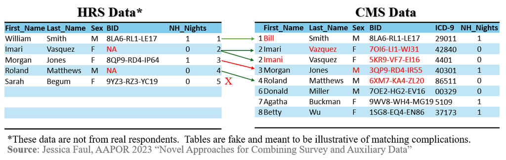

## Evaluating Linkage Quality

- **Objective**: Quantifying linkage uncertainty in linked datasets.
- **Linkage Errors**:
  - False matches (mismatches): Incorrect links (i.e., contaminate data).
  - False non-matches: Missed links (i.e., sample selection).
- Examples of linkage paradata include match status predictors, mismatch rate, safe matches, or blocking variables.
- E.g., `fastLink::confusion()`, `clevr` package.

Example Output: `fastLink::confusion()`

Posterior-Expected Classification Summary

$confusion.table

| Decision \ Truth | ‘True’ Matches | ‘True’ Non-Matches |
| --- | --- | --- |
| Declared Matches | 950.40 | 49.60 |
| Declared Non-Matches | 41.60 | 8958.40 |

**False Discovery Rate = 1 − PPV:** 49.60 / 1,000 = 4.96% (~5%)

**False Negative Rate = 1 − Sens.:** 41.60 / 992.0 = 4.19%

$addition.info

| Metric | results |
| --- | --- |
| Max Number of Obs to be Matched | 10000.00 |
| Sensitivity (%) | 95.81 |
| Specificity (%) | 99.45 |
| Positive Predicted Value (%) | 95.04 |
| Negative Predicted Value (%) | 99.54 |
| False Positive Rate (%) | 0.55 |
| False Negative Rate (%) | 4.19 |
| Correctly Clasified (%) | 99.09 |
| F1 Score (%) | 95.42 |

## Post-Linkage Data Analysis

- **Objective**: Valid statistical inference.
- **Analysis Settings**:
  - **Primary Analysis**: Source files are accessible; RL and analysis can be performed jointly to propagate uncertainty.
  - **Secondary Analysis**: Only the linked file may be accessible. Linkage paradata may be limited or unavailable.
- E.g., Standard functions (`glm`, `coxph`), `representr` and `MatchThem` packages.
- Literature focuses on false matches.

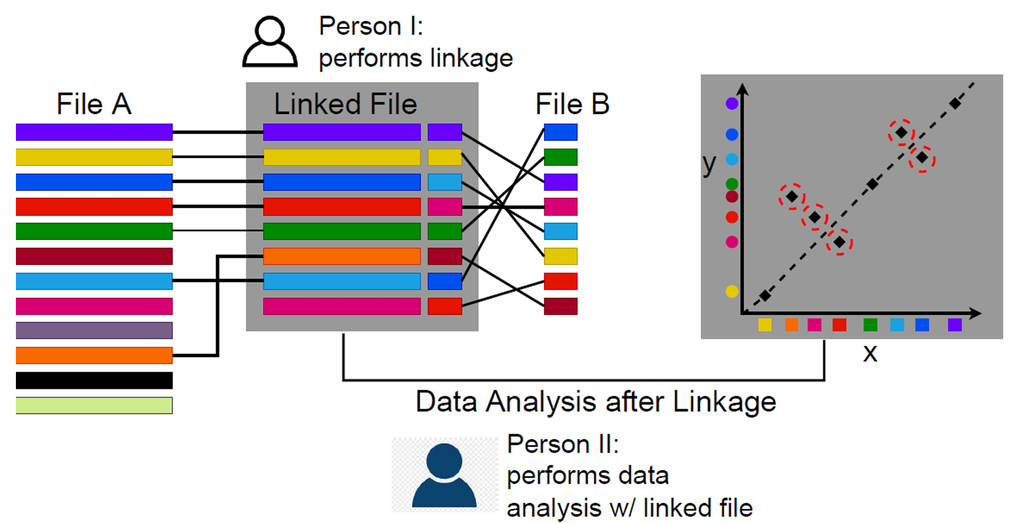

Secondary Analysis: Separation between linkage (**Person I**) and downstream analysis (**Person II**), where false matches (red circles) may distort regression relationships.

## [Overview](https://postlink-group.github.io/postlink/articles/postlink.html) of the `postlink` R Package

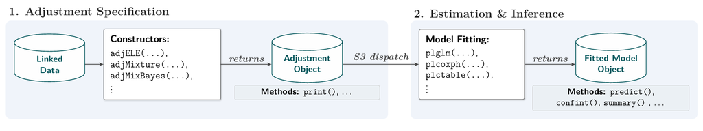

Schematic of the typical two-phase `postlink` workflow, decoupling the adjustment specification from the model fitting of interest.

- Builds on precursor `pldamixture` R Package.
- Implements three lines of adjustment methods for secondary analysis.

## Adjustment Methods for Secondary Analysis

| Framework | Constructor | Primary Use Case | Supported Models |
| --- | --- | --- | --- |
| Weighting | `adjELE()` | When block-level mismatch rates are given (e.g., from audit samples). | GLMs, CoxPH |
| Mixture Modeling | `adjMixture()` | When continuous or categorical paradata on linkage quality (e.g., string distances) are available. | GLMs, CoxPH, Contingency Tables |
| Bayesian Mixture | `adjMixBayes()` | When exploring multiple scientific models or to incorporate prior knowledge. | GLM, Parametric Survival |

An overview of three lines of adjustment methods implemented in `postlink`.

## [Quick Demonstration](https://postlink-group.github.io/postlink/articles/longevity-analysis.html)

- LIFE-M: open access, multi-generational data from the 20th century.
- Data gathered from vital records and decennial censuses.

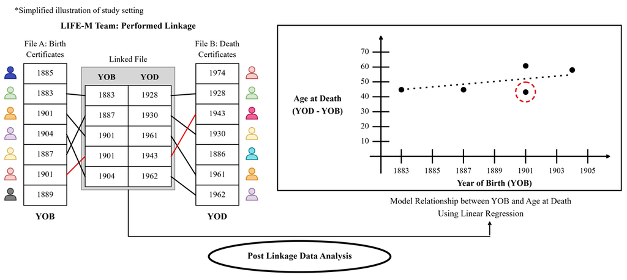

- RL was “hand-linked” or “machine-linked” (~5% anticipated mismatches).

## Linked Dataset

```r
l<-"https://github.com/postlink-group/postlink/releases/download/v0.1.2/lifem.rds"
lifem_data <- readRDS(url(l, "rb"))

head(lifem_data, n = 5) # 156,453 records w/ 6 variables
```

```
   yob unit_yob age_at_death hndlnk commf comml
1 1905    0.957           83  FALSE  0.77  0.45
2 1883    0.000           79   TRUE  0.93  0.08
3 1886    0.130           58  FALSE  0.89  0.80
4 1885    0.087           58  FALSE  0.72  0.42
5 1886    0.130           42  FALSE  0.74  0.61
```

- `yob`: year of birth (value from 1883 to 1906).
- `unit_yob`: year of birth (`yob`) rescaled to the interval [0,1].
- `age_at_death`: age at death (in years).
- `hndlnk`: indicator of hand-linkage at some level (`TRUE` or `FALSE`).
- `commf`, `comml`: “commonness” scores of first and last names. Ratio of the log count of name and the log count of the most frequently used name in the 1940 Census.